# Distribution Exploration

## Exploring distributions and related probability concepts

### Normal

Key concepts, using the Normal distribution as a starting point.

#### Generate Normal Distribution

Generate a random set of numbers that follow a specified normal distribution.

```r
m <- 50
std <- 10
norm_01 <- rnorm(n=1000, mean=m, sd=std)
```

Normal distribution with:

- Mean: 50
- Std. deviation: 10

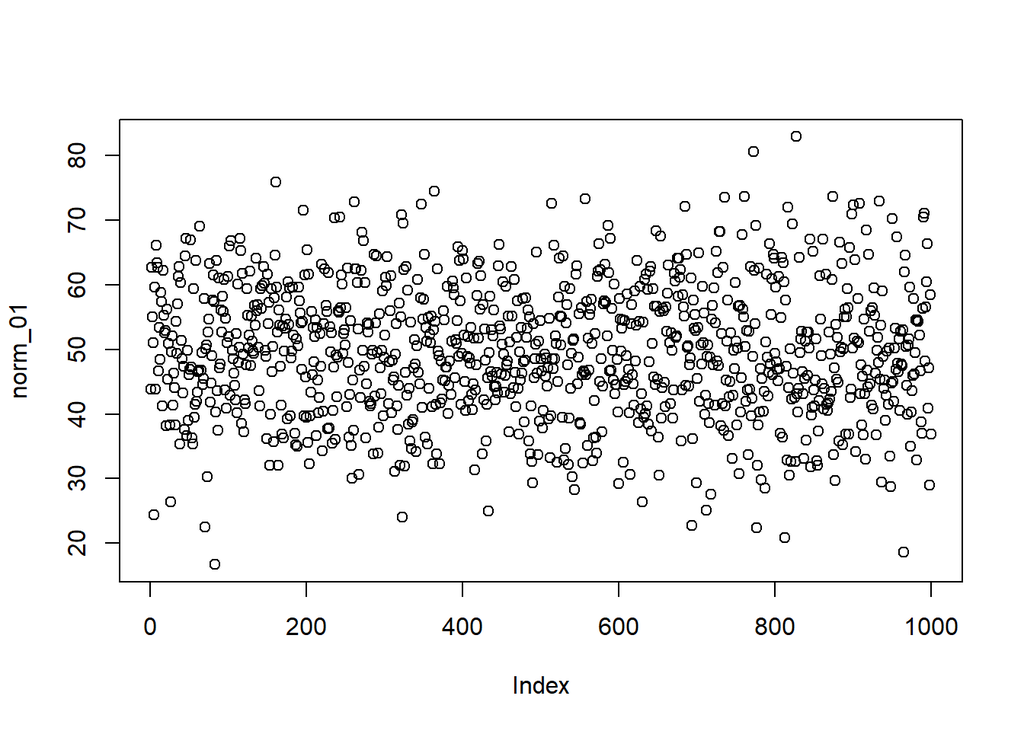

```r
plot(norm_01)
```

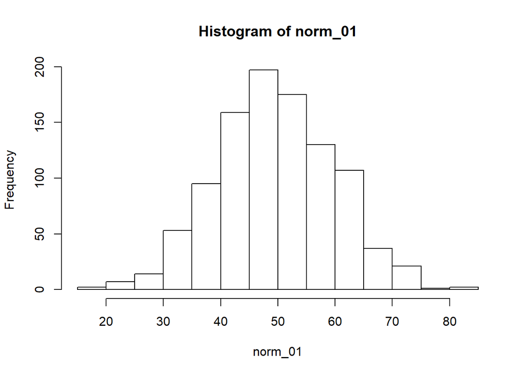

```r
hist(norm_01)
```

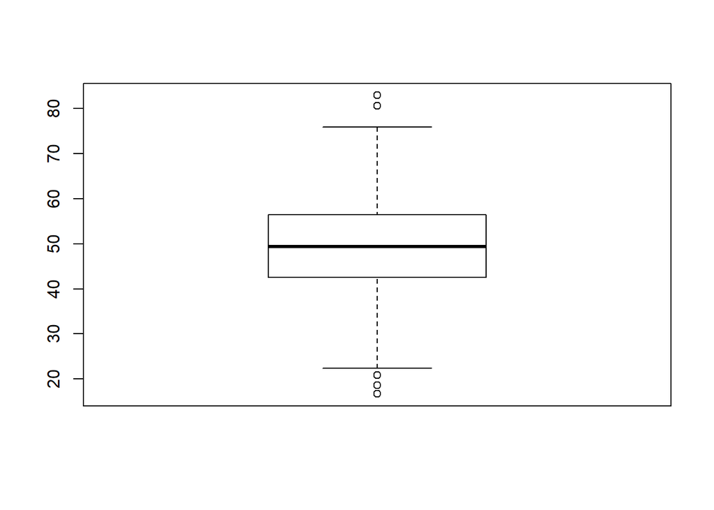

```r
boxplot(norm_01)
```

Convert to data frame use with ggplot and additional features therein. Get summary statistics.

```r
df_norm_01 <- data.frame(values=norm_01)

summary(df_norm_01)
```

```
##      values
##  Min.   :16.71
##  1st Qu.:42.59
##  Median :49.42
##  Mean   :49.58
##  3rd Qu.:56.47
##  Max.   :82.92
```

```r
print(paste0('Std dev: ', sd(df_norm_01$values)))
```

```
## [1] "Std dev: 10.2141981450984"
```

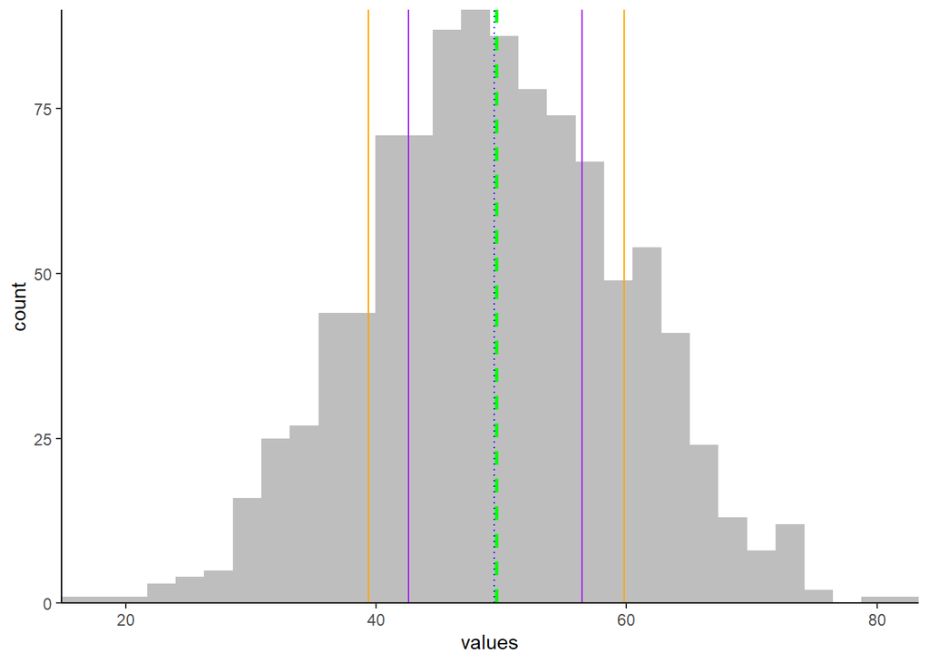

```r
ggplot(df_norm_01, aes(x=values))+geom_histogram(fill='grey')+
  geom_vline(xintercept = mean(df_norm_01$values), color='green', linetype='dashed', size=1)+
  geom_vline(xintercept = median(df_norm_01$values), color='blue', linetype='dotted')+
  geom_vline(xintercept=quantile(df_norm_01$values, 0.25), color='purple')+
  geom_vline(xintercept = quantile(df_norm_01$values, 0.75), color='purple')+
  geom_vline(xintercept=mean(df_norm_01$values)-sd(df_norm_01$values), color='orange')+
  geom_vline(xintercept=mean(df_norm_01$values)+sd(df_norm_01$values), color='orange')+
  scale_y_continuous(expand=c(0,0))+
  scale_x_continuous(expand=c(0,0))+
  theme_classic()
```

- Green = mean
- Blue = median
- Purple = 25th and 75th percentiles
- Orange = 1 std dev, above and below mean

Convert histogram to density function, with probabilities on y-axis:

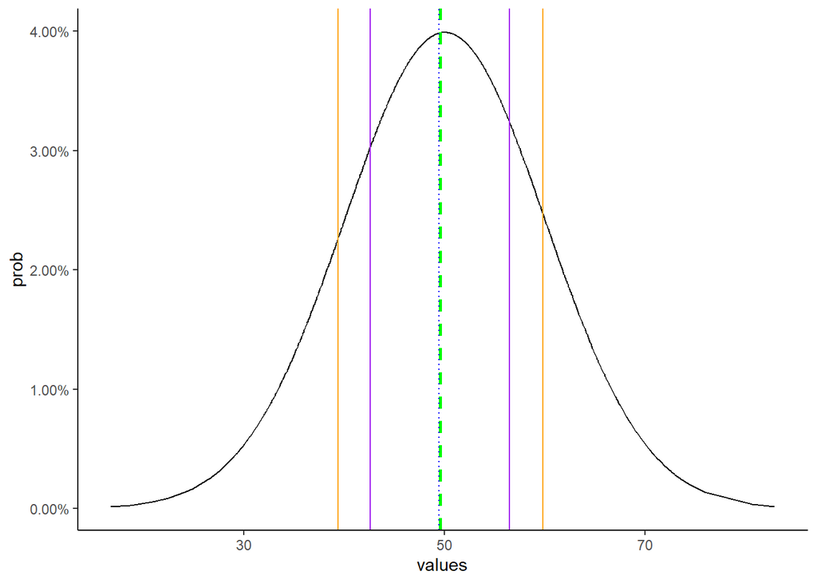

```r
df_norm_01 <- df_norm_01 %>% mutate(
  prob=dnorm(values, mean=m, sd=std)
)

ggplot(df_norm_01, aes(x=values, y=prob))+geom_line()+
  geom_vline(xintercept = mean(df_norm_01$values), color='green', linetype='dashed', size=1)+
  geom_vline(xintercept = median(df_norm_01$values), color='blue', linetype='dotted')+
  geom_vline(xintercept=quantile(df_norm_01$values, 0.25), color='purple')+
  geom_vline(xintercept = quantile(df_norm_01$values, 0.75), color='purple')+
  geom_vline(xintercept=mean(df_norm_01$values)-sd(df_norm_01$values), color='orange')+
  geom_vline(xintercept=mean(df_norm_01$values)+sd(df_norm_01$values), color='orange')+
  scale_y_continuous(labels=percent)+
  theme_classic()
```

Plot the cumulative distrbution function for this data:

- can be read as cumulative percentiles on the left

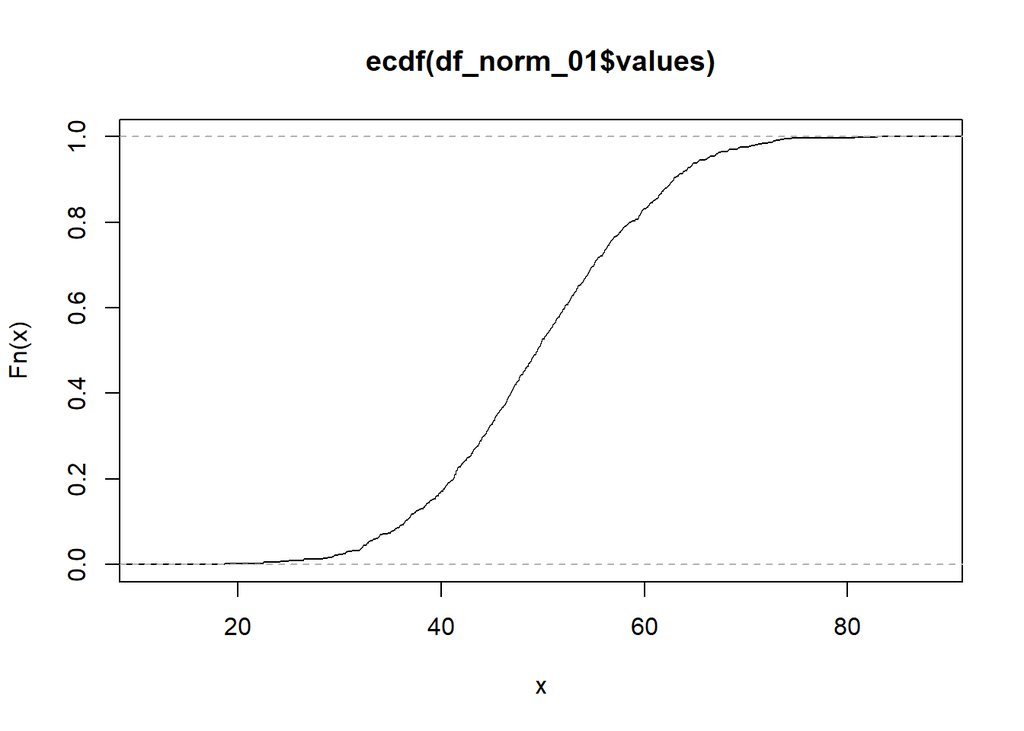

```r
plot(ecdf(df_norm_01$values))
```

Can create the same by applying pnorm() to the data and drawing with ggplot2:

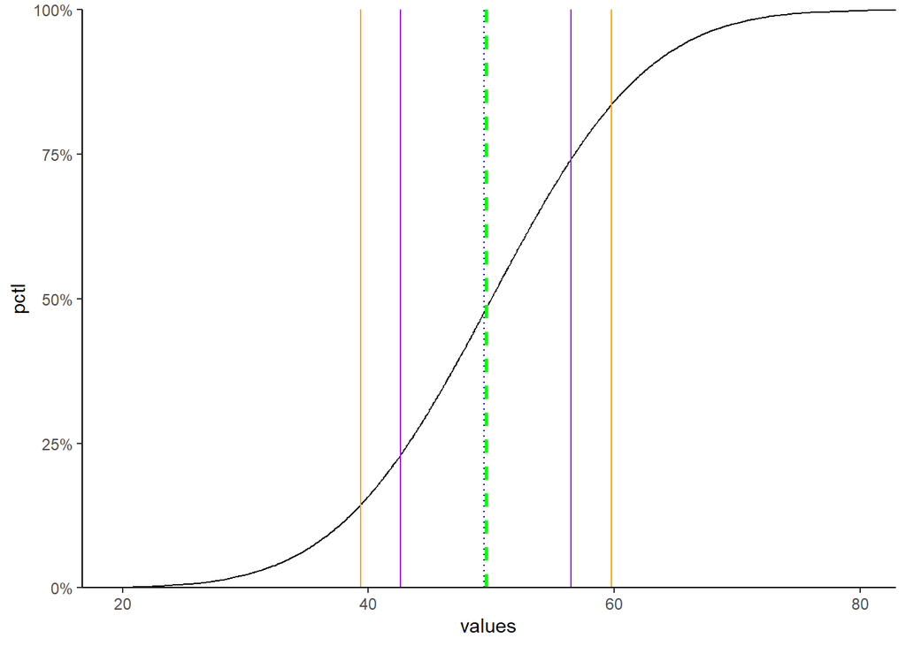

```r
df_norm_01 <- df_norm_01 %>% mutate(
  pctl = pnorm(values, mean=m, sd=std)
)

ggplot(df_norm_01, aes(x=values, y=pctl))+geom_line()+
  geom_vline(xintercept = mean(df_norm_01$values), color='green', linetype='dashed', size=1)+
  geom_vline(xintercept = median(df_norm_01$values), color='blue', linetype='dotted')+
  geom_vline(xintercept=quantile(df_norm_01$values, 0.25), color='purple')+
  geom_vline(xintercept = quantile(df_norm_01$values, 0.75), color='purple')+
  geom_vline(xintercept=mean(df_norm_01$values)-sd(df_norm_01$values), color='orange')+
  geom_vline(xintercept=mean(df_norm_01$values)+sd(df_norm_01$values), color='orange')+
  scale_x_continuous(expand=c(0,0))+
  scale_y_continuous(labels=percent, expand=c(0,0), limits=c(0,1))+
  theme_classic()
```

#### Probabilities

What is the probability of value X as an outcome?

```r
x <- 40
dnorm(x=x, mean=m, sd=std)
```

```
## [1] 0.02419707
```

A single number in a continous distribution, so the probability will be low.

What is the PROBABILITY of an outcome of X or LOWER?

```r
x <- mean(df_norm_01$values)-sd(df_norm_01$values)
pnorm(q=x, mean=m, sd=std)
```

```
## [1] 0.1437305
```

what is the PROBABILITY of an outcome BETWEEN X and Y?

```r
x <- x
y <- mean(df_norm_01$values)+sd(df_norm_01$values)
p_lower <- pnorm(q=x, mean=m, sd=std)
p_upper <- pnorm(q=y, mean=m, sd=std, lower.tail=FALSE)
pxy <- 1-(p_lower+p_upper)
```

Probability of an outcome between 39.3629213 and 59.7913176 is: 0.692512.

What is PROBABILITY of X or HIGHER?

Probability of outcome higher than 59.7913176 is: 0.1637574. (lower.tail=FALSE gets upper tail)

How many STANDARD DEVIATIONS is a given number from the mean?

```r
## How far is x from mean, in std devs?
x
```

```
## [1] 39.36292
```

```r
(x-m)/std
```

```
## [1] -1.063708
```

What numberS and STANDARD DEVIATIONS match different PERCENTILES?

```r
## How far is 95th percentile from mean, in std devs?
## 95th percentile
pct <- 0.95
pctle <- paste0(pct*100,'th percentile')
pctle
```

```
## [1] "95th percentile"
```

```r
qtle <- qnorm(p=pct, mean=m, sd=std)
qtle
```

```
## [1] 66.44854
```

```r
paste0(round((qtle-m)/std,2), ' std devs')
```

```
## [1] "1.64 std devs"
```

```r
## 97.5th percentile
pct <- 0.975
pctle <- paste0(pct*100,'th percentile')
pctle
```

```
## [1] "97.5th percentile"
```

```r
qtle <- qnorm(p=pct, mean=m, sd=std)
qtle
```

```
## [1] 69.59964
```

```r
paste0(round((qtle-m)/std,2), ' std devs')
```

```
## [1] "1.96 std devs"
```

```r
## 99th percentile
pct <- 0.99
pctle <- paste0(pct*100,'th percentile')
pctle
```

```
## [1] "99th percentile"
```

```r
qtle <- qnorm(p=pct, mean=m, sd=std)
qtle
```

```
## [1] 73.26348
```

```r
paste0(round((qtle-m)/std,2), ' std devs')
```

```
## [1] "2.33 std devs"
```

- 1.64 standard deviations from the mean is the largest change you will get 95% of the time. This is looking at distance from the mean on a one-sided basis.
- 1.96 standard deviations cover 95% of the total range of values above/below the mean in a normal distribution, but that is actually the 97.5% percentile with 2.5% on each of the upper and lower tails.
- one-tail (one-sided) used for things like financial risk management when you are most focused on one direction (downside)
  - so 99% of the time you won’t see loss worse than 2.33 std dev

### Poisson

- for discrete random variable to determine probability of x occurences of an event over specific interval of time
- works best with small number of events (10 or less) in small time interval (1 or less)
- at smaller valuse of lambda (<10), has strong right skew
- at larger values of lambda, approaches normal - probably because at smaller values, there is more potential upside than downside, since can’t be negative

#### Generate Poisson

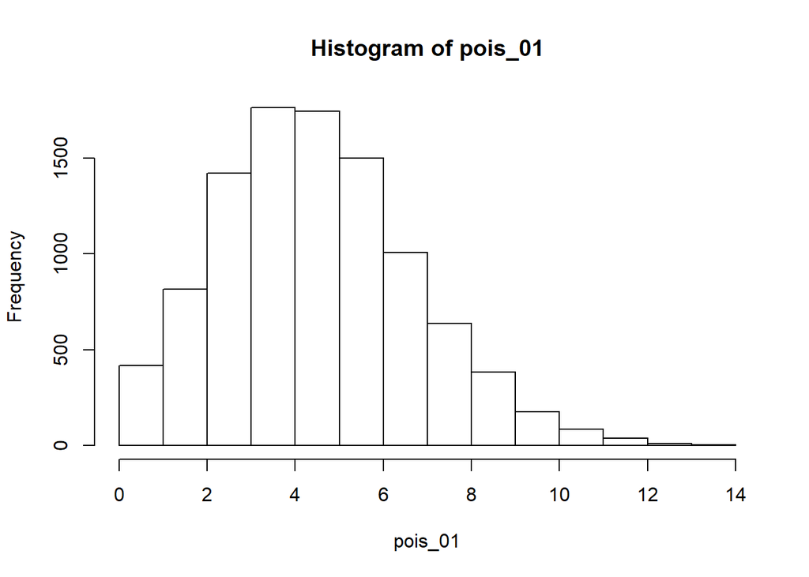

```r
nn <- 10000
lmb <- 5
pois_01 <- rpois(n=nn, lambda=lmb)
hist(pois_01)
```

#### Probability distribution

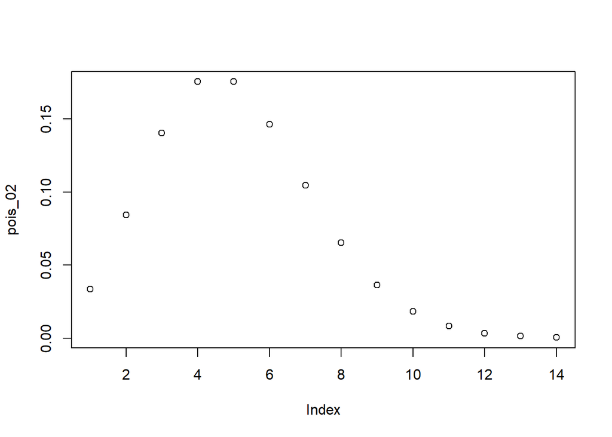

```r
xx <- c(1:max(pois_01))
lmb <- 5
pois_02 <- dpois(x=xx, lambda=lmb)
plot(pois_02)
```

#### Example

https://www.youtube.com/watch?v=m_c1nIC2Dfo

- website gets average 10 visits per minute

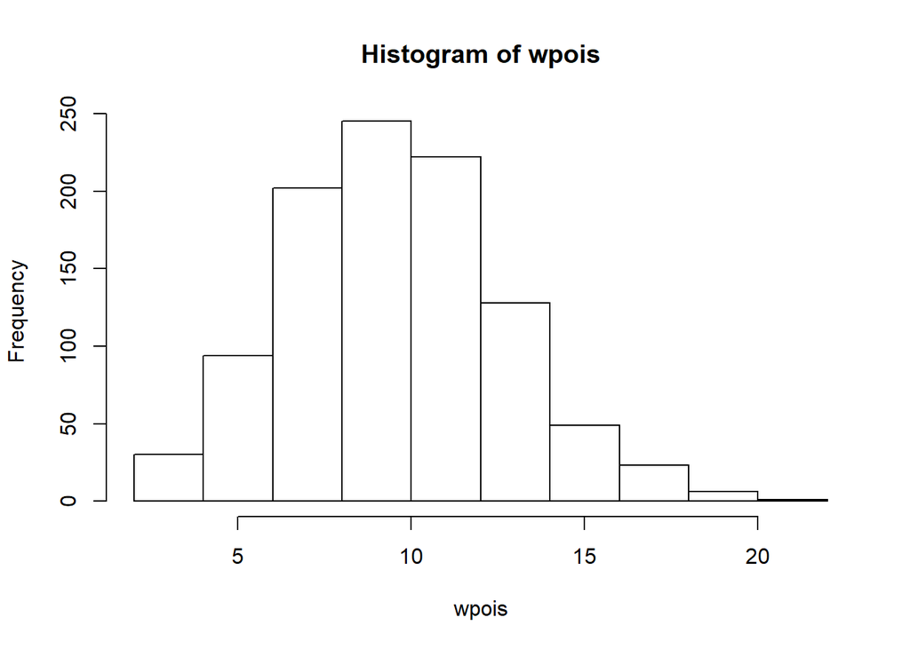

```r
nn <- 1000
lmb <- 10
wpois <- rpois(n=nn, lambda = lmb)
hist(wpois)
```

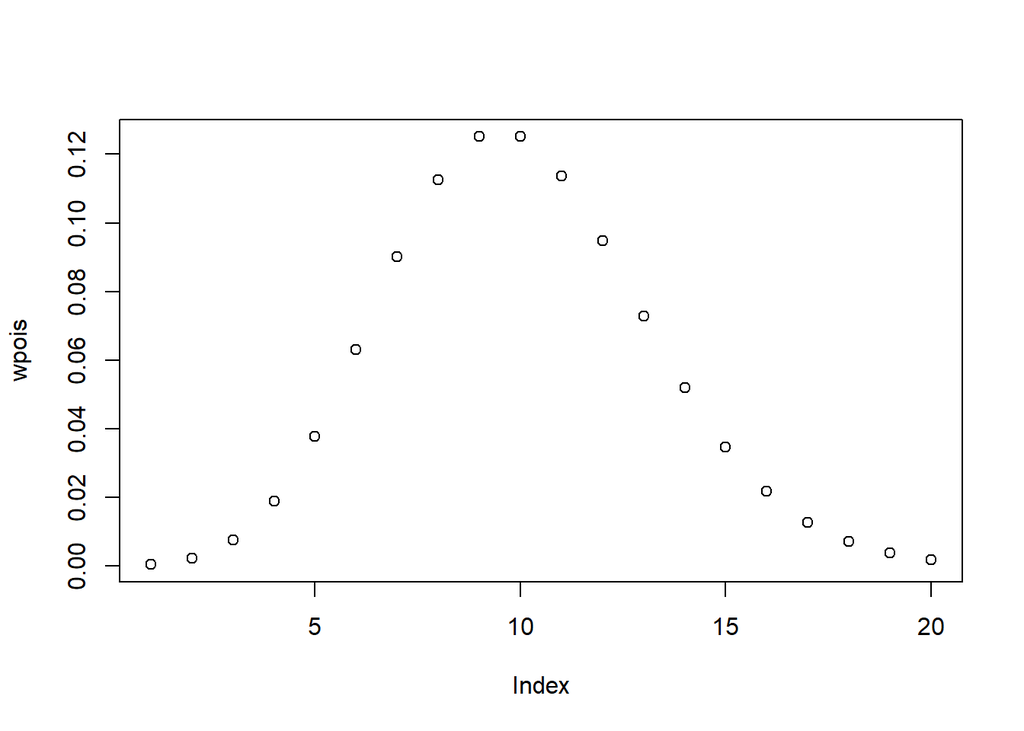

```r
xx <- c(1:20)
wpois <- dpois(x=xx, lambda = lmb)
plot(wpois)
```

```r
w1 <- 3
lmb <- 10
wdpois <- dpois(x=w1, lambda=lmb)
print(paste0("3 visits: ", wdpois*100, " percent"))
```

```
## [1] "3 visits: 0.756665496041415 percent"
```

```r
wppois <- ppois(q=w1, lambda = lmb)
print(paste0(w1, " visits or less: ", wppois*100, " percent"))
```

```
## [1] "3 visits or less: 1.03360506759257 percent"
```

```r
w1 <- 12
wppois <- ppois(q=w1, lambda = lmb, lower.tail=FALSE)
print(paste0("More than ",w1, " visits: ", wppois*100, " percent"))
```

```
## [1] "More than 12 visits: 20.8443523605126 percent"
```

Based on the above distribution, what if you wanted to know how many visits per day?

- create data frame for distribution based on minute
- multiply up
- (not sure if this is legit, though?)

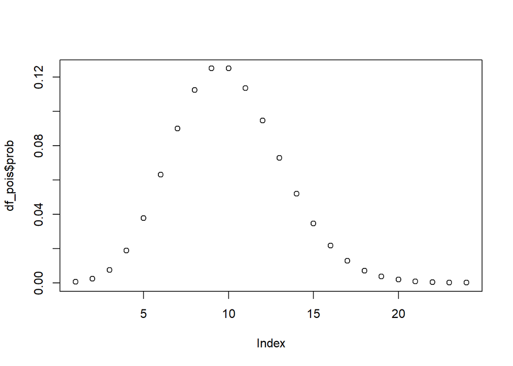

```r
vpm <- 10
df_pois <- data.frame(visits=c(1:24))
#df_pois$prob <- dpois(x=df_pois$visits, lambda=10)
df_pois <- df_pois %>% mutate(
  prob=dpois(x=visits, lambda=vpm),
  cprob=ppois(q=visits, lambda=vpm)
)

plot(df_pois$prob)
```

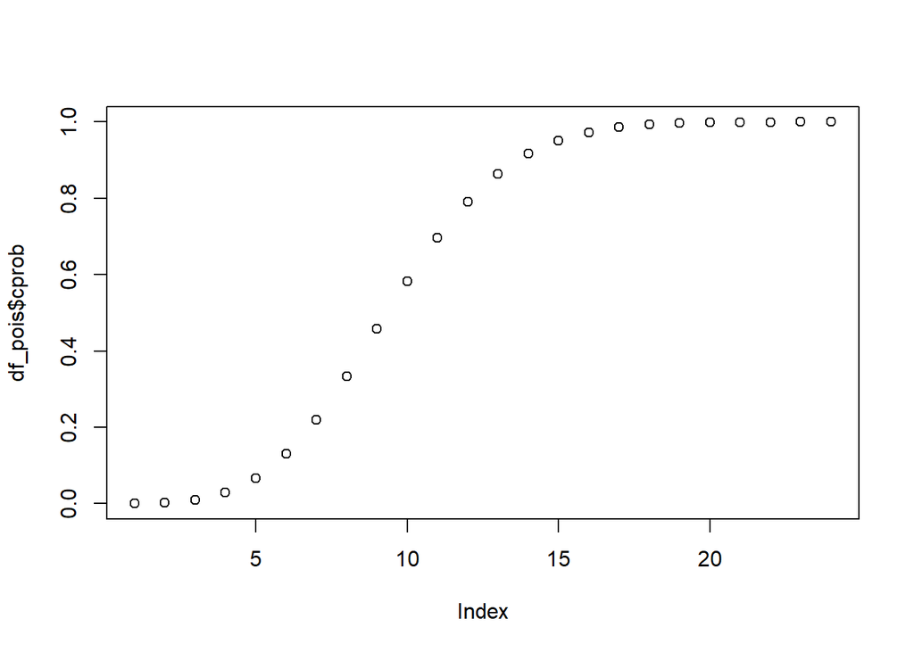

```r
plot(df_pois$cprob)
```

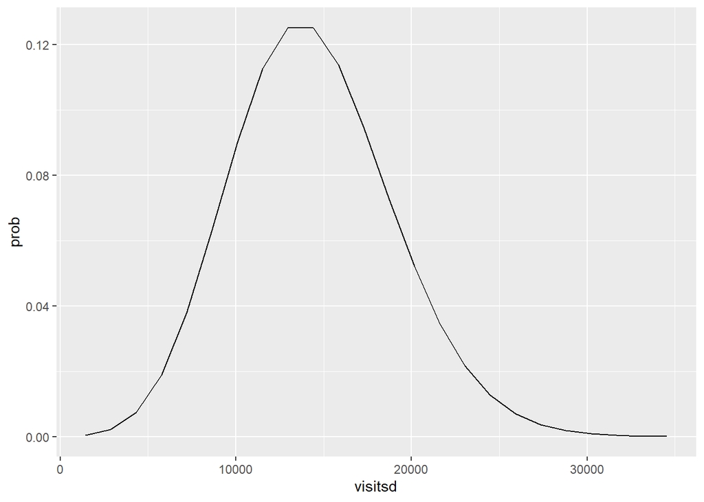

```r
df_pois <- df_pois %>% mutate(
  visitsd=visits*60*24
)

ggplot(df_pois, aes(x=visitsd, y=prob))+geom_line()
```

Or to simulate the data…

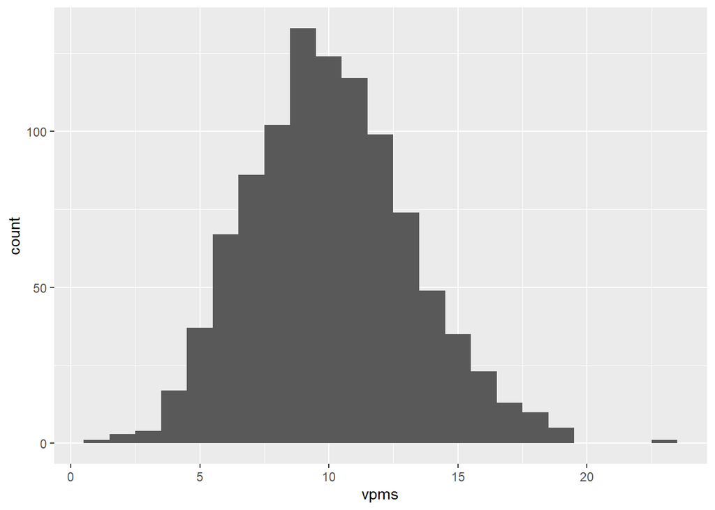

```r
nn <- 1000
df_pois_sim <- data.frame(vpms=rpois(n=nn, lambda=vpm))
df_pois_sim <- df_pois_sim %>% mutate(
  vpd=vpms*60*24
)
ggplot(df_pois_sim, aes(x=vpms))+geom_histogram(binwidth = 1)
```

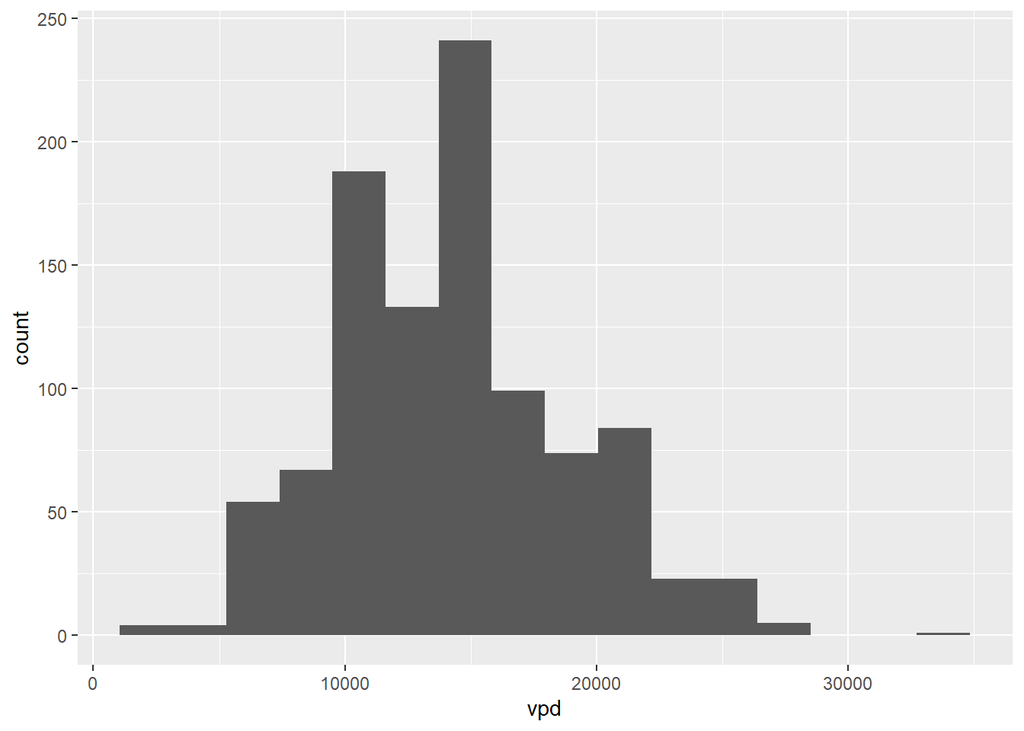

```r
## set bindwidth by calc
bw <- (max(df_pois_sim$vpd)-min(df_pois_sim$vpd))/15
## plot vpd
ggplot(df_pois_sim, aes(x=vpd))+geom_histogram(binwidth=bw)
```

### Gamma family

Gamma is actually a family of distributions. It seems to offer better replication of skewed distributions than Poisson.

From https://www.rocscience.com/help/swedge/swedge/Gamma_Distribution.htm:

- The Gamma distribution is widely used in engineering, science, and business, to model continuous variables that are always positive and have skewed distributions.
- a (alpha) is known as the shape parameter, while b (beta) is referred to as the scale parameter.
- b has the effect of stretching or compressing the range of the Gamma distribution. A Gamma distribution with b = 1 is known as the standard Gamma distribution.

The Gamma distribution represents a family of shapes. As suggested by its name, a controls the shape of the family of distributions. The fundamental shapes are characterized by the following values of a:

Case I (a < 1)

- When a < 1, the Gamma distribution is exponentially shaped and asymptotic to both the vertical and horizontal axes.

Case II (a = 1)

- Gamma distribution with shape parameter a = 1 and scale parameter b is the same as an exponential distribution of scale parameter (or mean) b.

Case III (a > 1)

- When a is greater than one, Gamma distribution assumes a mounded (unimodal), skewed shape. Skewness reduces as the value of a increases.

There are two parameters and two variations on the parameter combinations. For simplicity, focus here is on:

- shape (a above, sometimes k) -> determines skew
- scale (b above, sometimes theta) -> determines stretch/compression of the range (can also use rate which equals 1/scale)

Some gamma distribution examples:

**(what does it mean when probability density >1 ???)**

1. Do not confuse ‘probability density’ with probability
2. Calculus
3. In practical terms, it can be interpreted as something like “at really small intervals, there is a high amount of density (frequency) here, *relative* to the overall distribution of values, and as a result some values have frequency of (close to) 0.”

```
## shape=1 rate=0.5
```

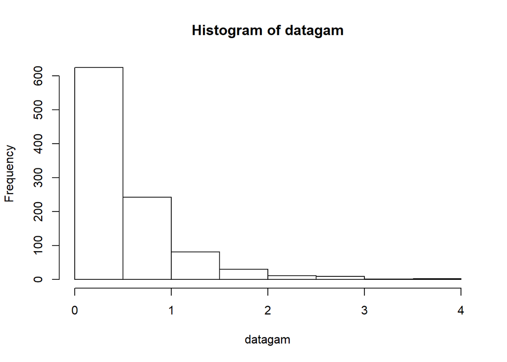

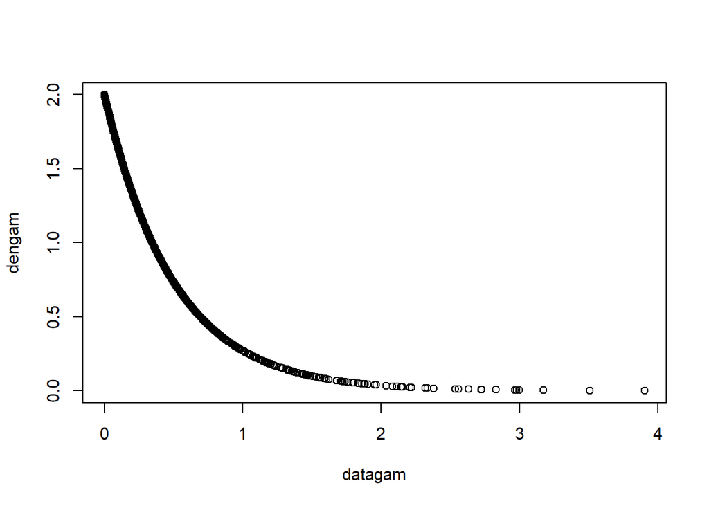

```r
## function to create gamma samples and density
fGammavardens <- function(num, sh, sc){
  shsc <- paste0('gamma','-',sh,':', sc)
  cat(paste0('shape=',sh,' rate=', sc))
  datagam <- rgamma(n=1000, shape=sh, scale=sc)
  plot.hist <- hist(datagam)
  #plot.hist <- ggplot(data.frame(datagam), aes(x=datagam))+geom_histogram()

  datagam <- round(datagam, 3)
  datagam <- unique(datagam)
  dengam <- dgamma(datagam, shape=sh, scale=sc)
  gam <- data.frame(datagam, dengam, ksc=shsc)
  plot.dense <- plot(data=gam, dengam~datagam)
  #plot.dense <- ggplot(gam, aes(x=datagam, y=dengam))+geom_line()+theme_classic()

  list(plot.hist, plot.dense)
  return(gam)
}

gam_all <- data.frame()

gamsample <- fGammavardens(1000, 1, 0.5)
```

```r
gam_all <- bind_rows(gam_all, gamsample)

gamsample <- fGammavardens(1000, 1, 1)
```

```
## shape=1 rate=1
```

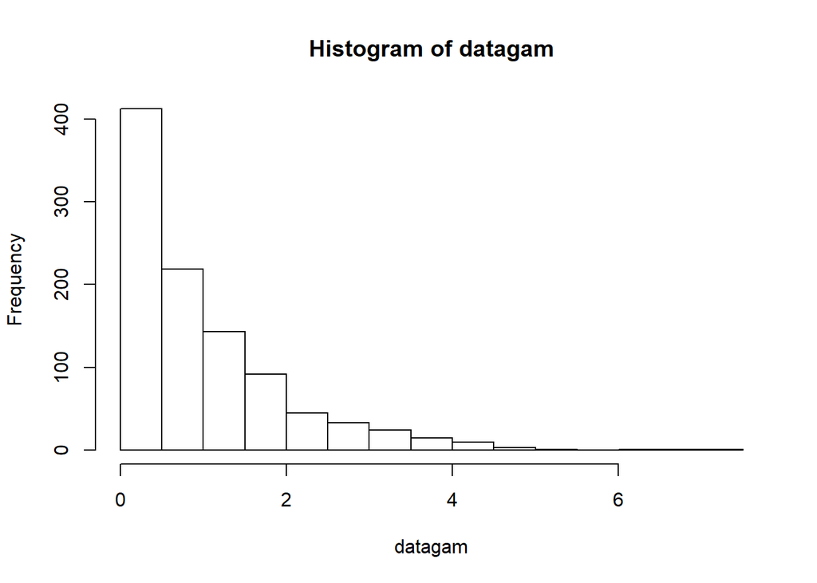

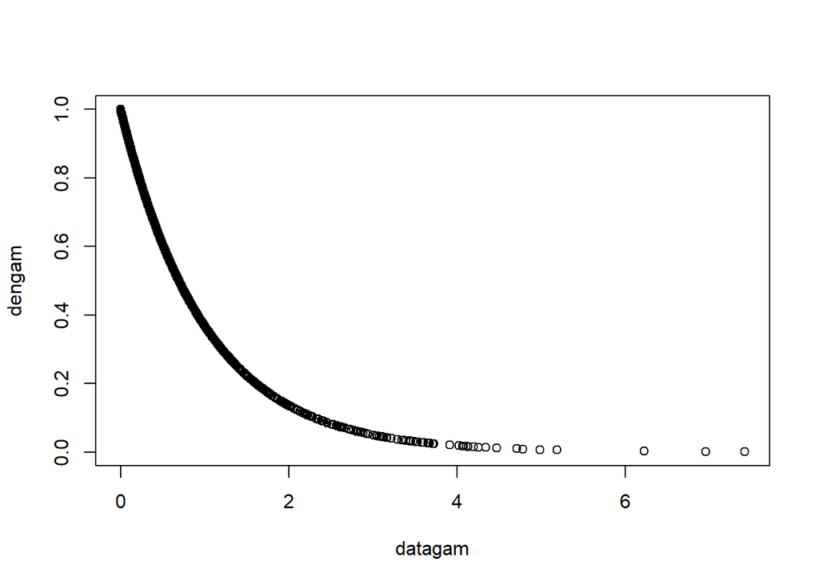

```r
gam_all <- bind_rows(gam_all, gamsample)

gamsample <- fGammavardens(1000, 1, 2)
```

```
## shape=1 rate=2
```

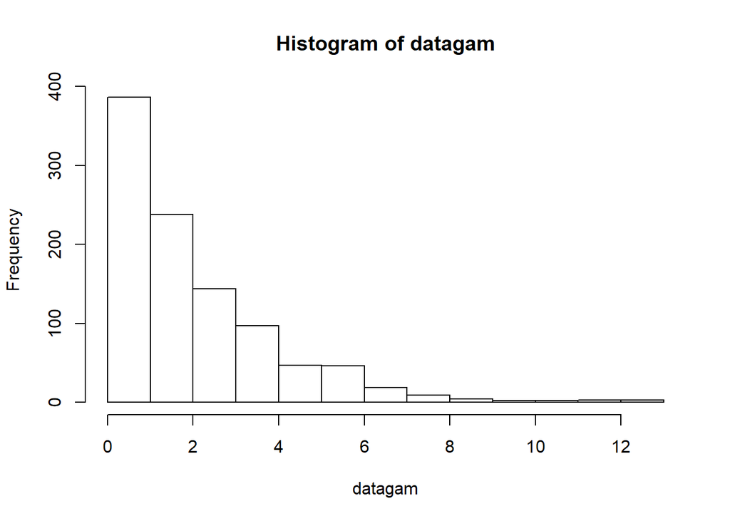

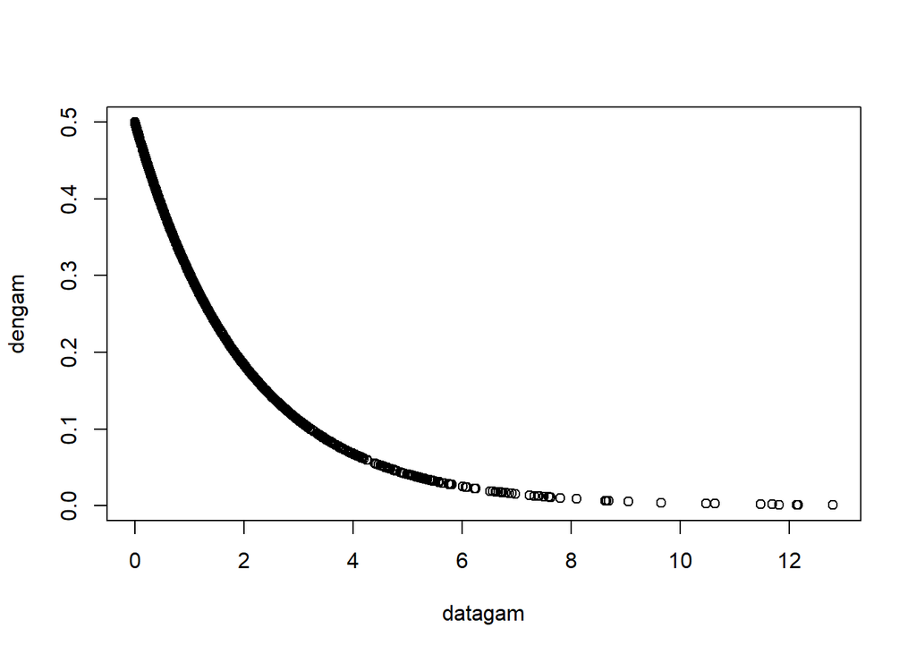

```r
gam_all <- bind_rows(gam_all, gamsample)

gamsample <- fGammavardens(1000, 2, 0.5)
```

```
## shape=2 rate=0.5
```

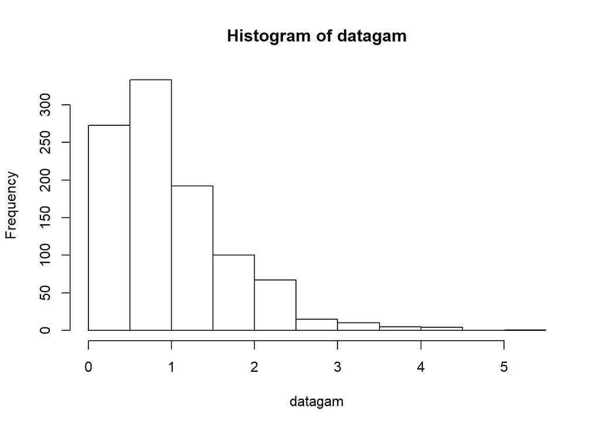

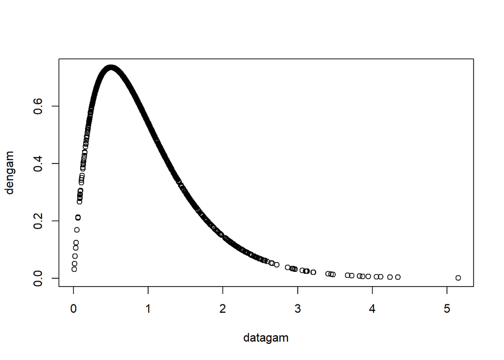

```r
gam_all <- bind_rows(gam_all, gamsample)

gamsample <- fGammavardens(1000, 2, 2)
```

```
## shape=2 rate=2
```

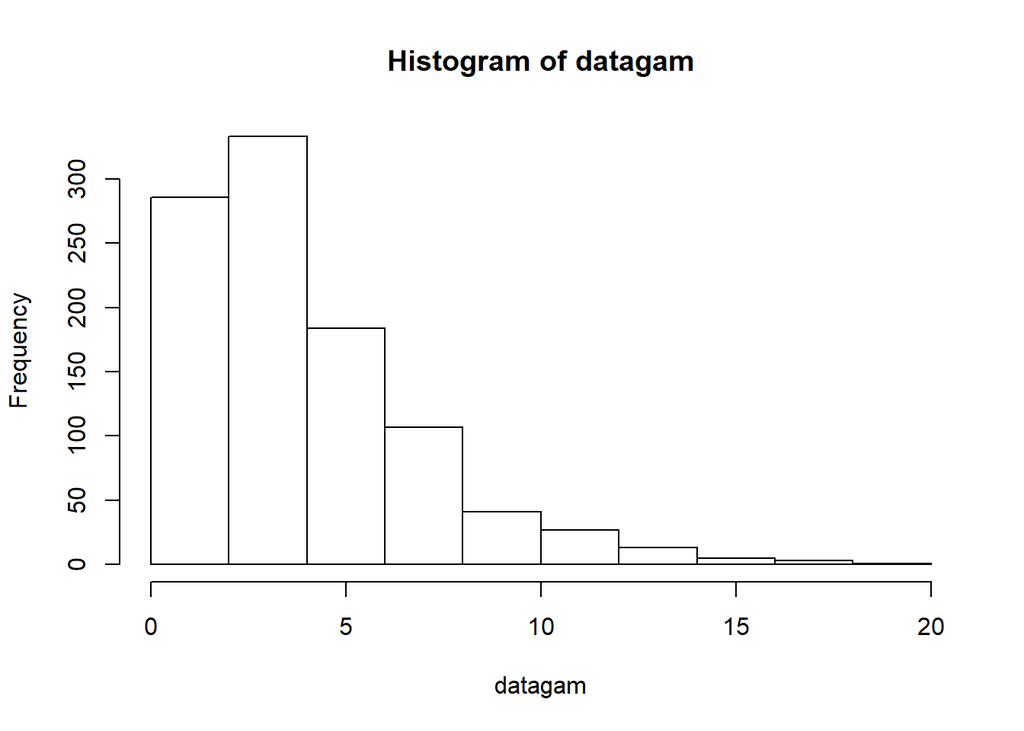

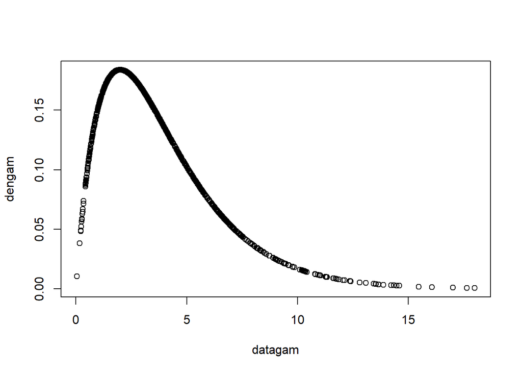

```r
gam_all <- bind_rows(gam_all, gamsample)

gamsample <- fGammavardens(1000, 3, 0.5)
```

```
## shape=3 rate=0.5
```

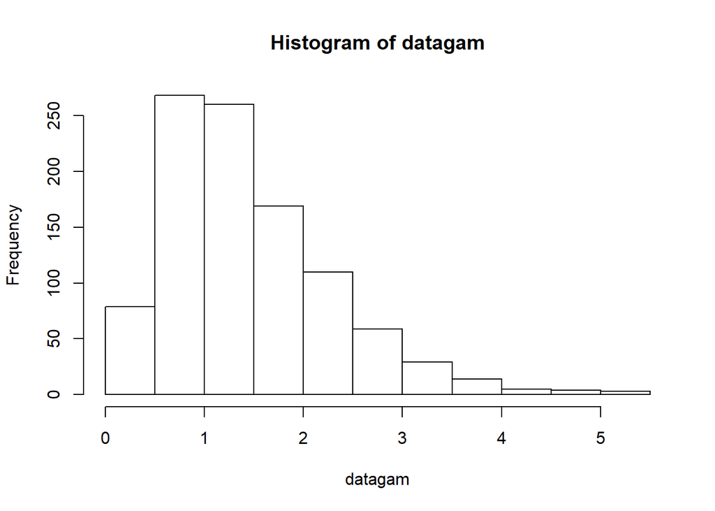

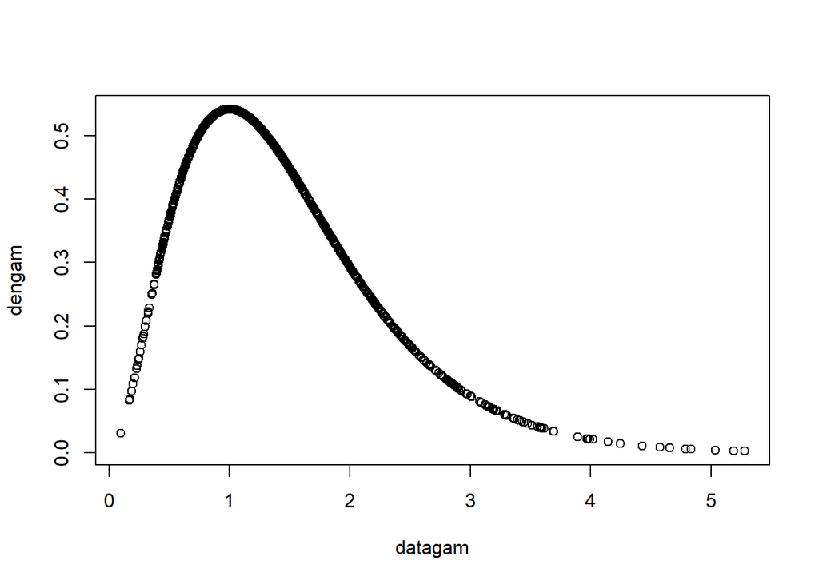

```r
gam_all <- bind_rows(gam_all, gamsample)

gamsample <- fGammavardens(1000, 3, 1)
```

```
## shape=3 rate=1
```

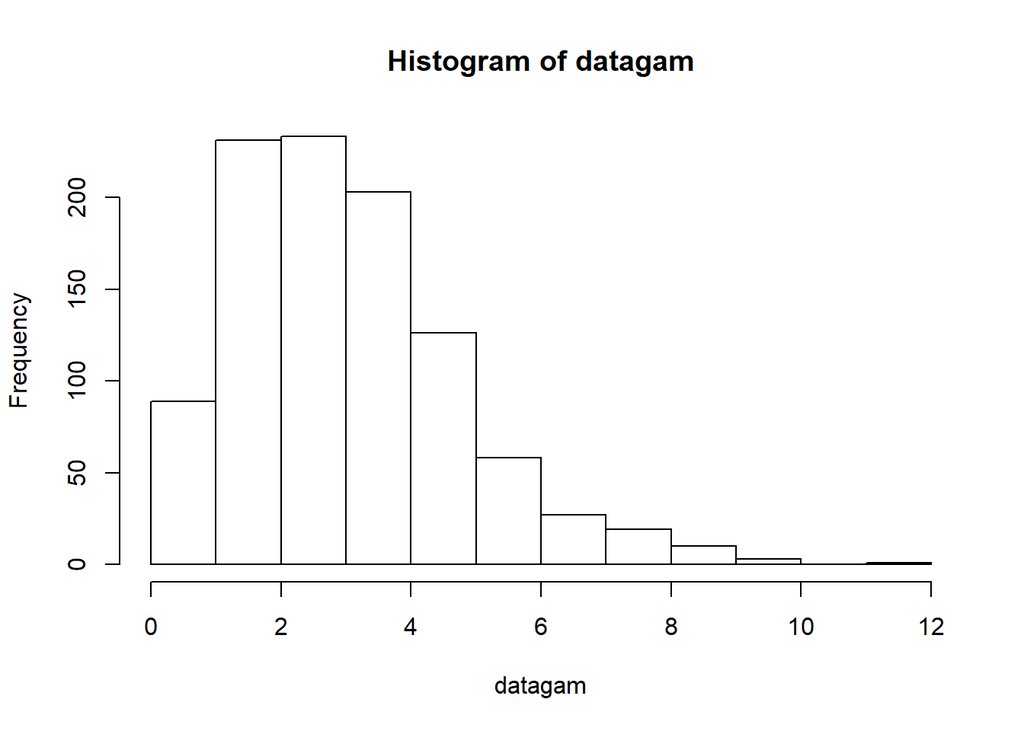

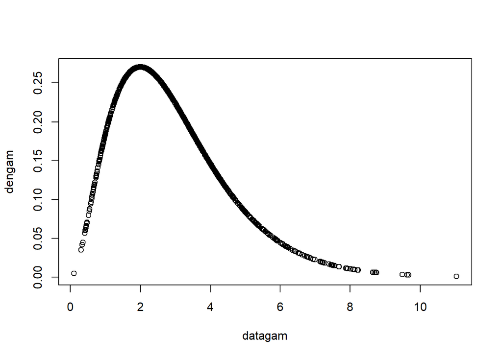

```r
gam_all <- bind_rows(gam_all, gamsample)

gamsample <- fGammavardens(1000, 5, 1)
```

```
## shape=5 rate=1
```

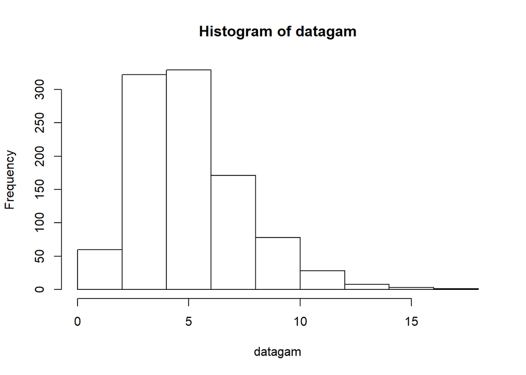

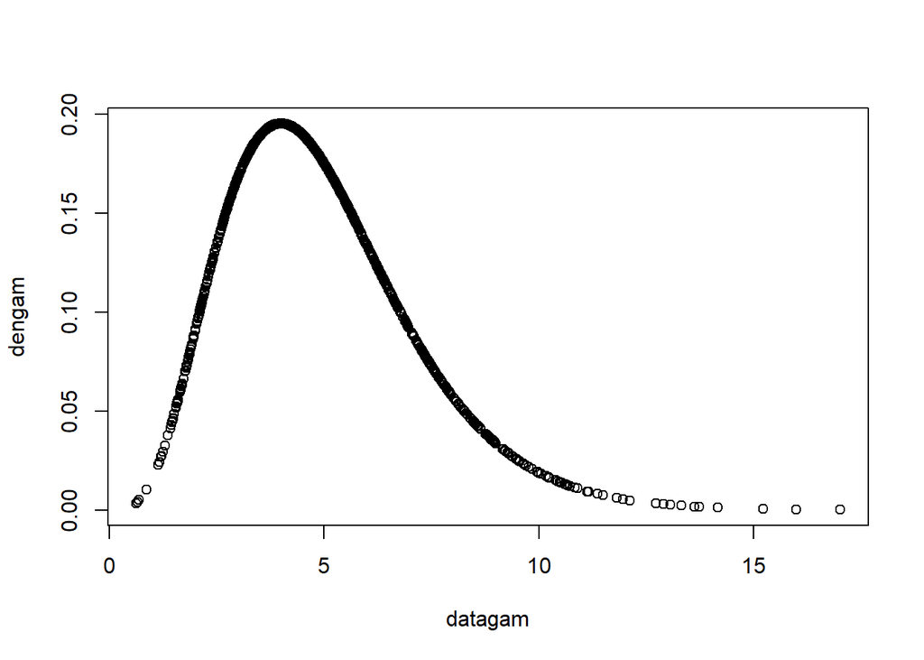

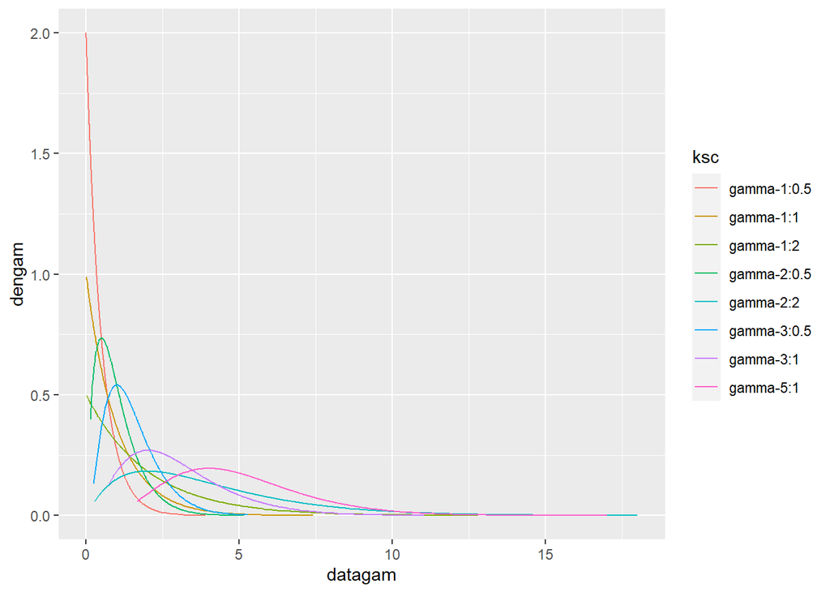

```r
gam_all <- bind_rows(gam_all, gamsample)


gam_all <- gam_all %>% distinct(datagam, .keep_all = TRUE)
ggplot(gam_all, aes(x=datagam, y=dengam, color=ksc))+
  geom_line()
```

### Exponential

As noted above, this is part of gamma. Treated here separately for additional exploration.

Inspired by info here: https://web.stanford.edu/class/bios221/labs/simulation/Lab_3_simulation.html

Exponential distribution functions:

- dexp, pexp, qexp, rexp

Because it is specific type of distribution (part of the gamma family), it has specific parameters (I guess). For rexp:

- ‘n’ appears to be equivalent to ‘shape’; looks like ‘1’ might be min value
- ‘rate’ corresponds to 1/scale in gamma distribution

```r
reps <- 5000
nexps <- 1 ## 1=full exponential; 2 highly right skewed; 20 almost normal
rate <- 0.1
set.seed(2019)
x1 <- replicate(n=reps, sum(rexp(n=nexps, rate=rate)))
```

Visualize results

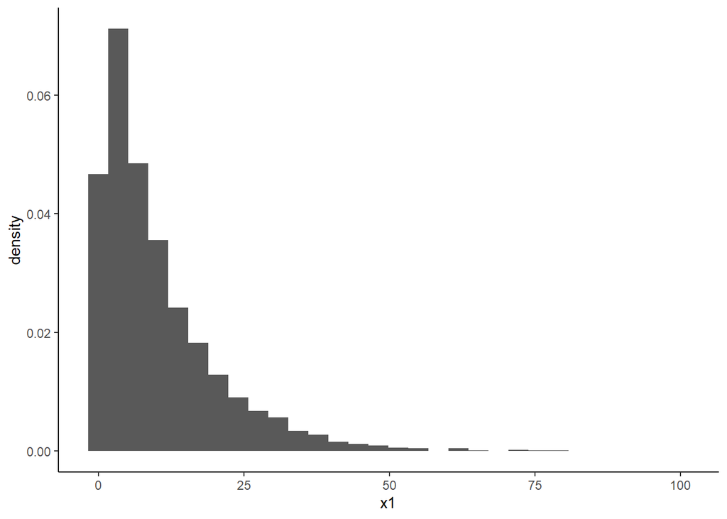

```r
ggplot(data.frame(x1), aes(x=x1))+
  geom_histogram(aes(y=..density..))+theme_classic()
```

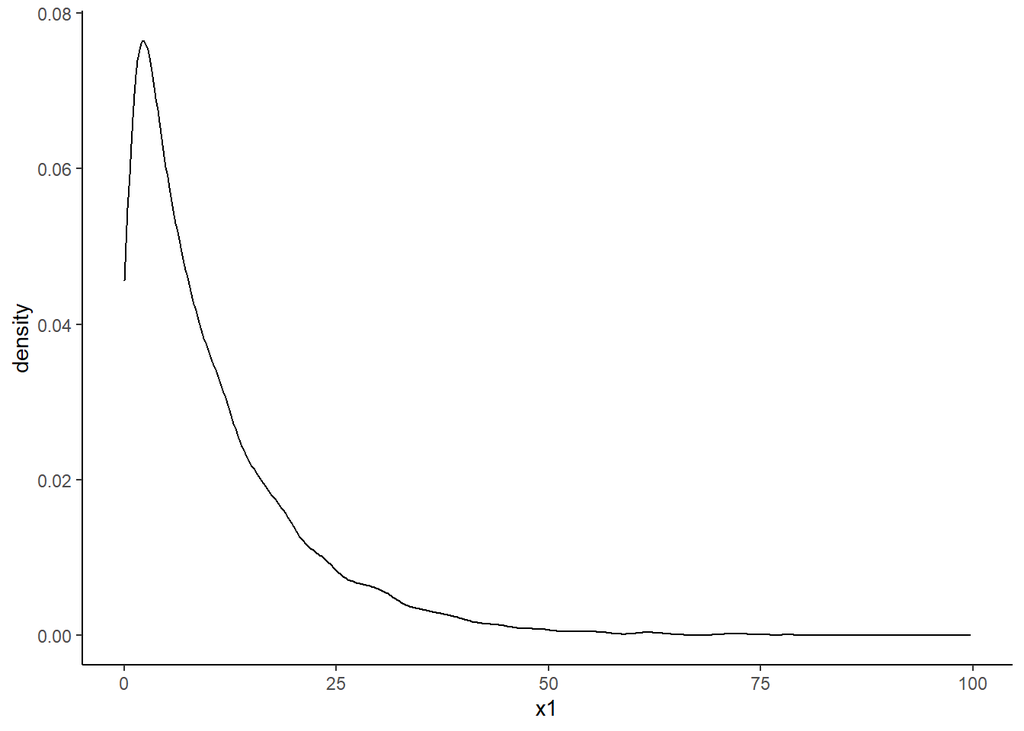

```r
ggplot(data.frame(x1), aes(x=x1))+
  geom_density()+theme_classic()
```

With comparison to theorectical distribution

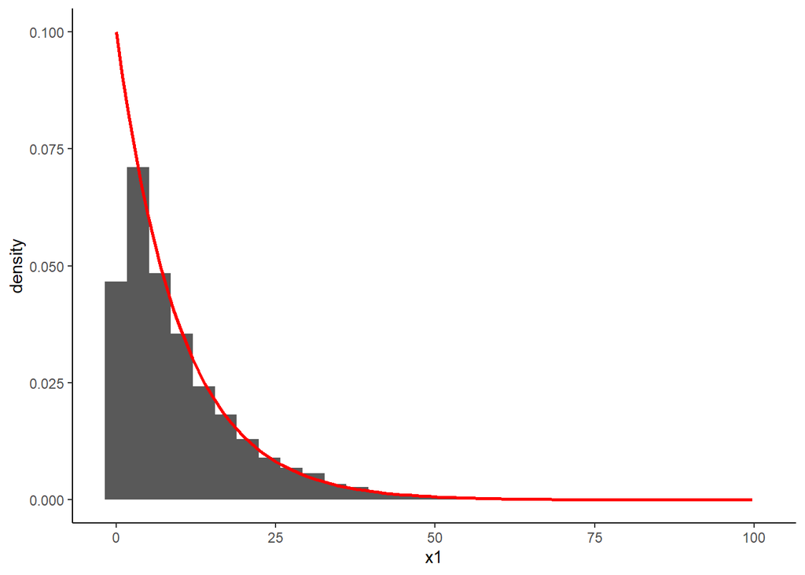

```r
ggplot(data.frame(x1), aes(x=x1))+
  geom_histogram(aes(y=..density..))+
  stat_function(fun=function(x)dgamma(x, shape=nexps, scale=1/rate), color='red', size=1)+
  theme_classic()
```

### Beta

Beta has two required parameters and one optional:

- shape1
- shape2
- ncp: non-centrality (optional)

Seems as though:

- shape1 < 1 < shape2: right skew
- shape1 > 1 > shape2: left skew equivalent to right skew on same values swapped
- strength of skew generally reflective of ratio of higher shape to lower
- shape1, shape2 = 1: pretty much uniform
- shape1, shape2 = 3+: approaches normality

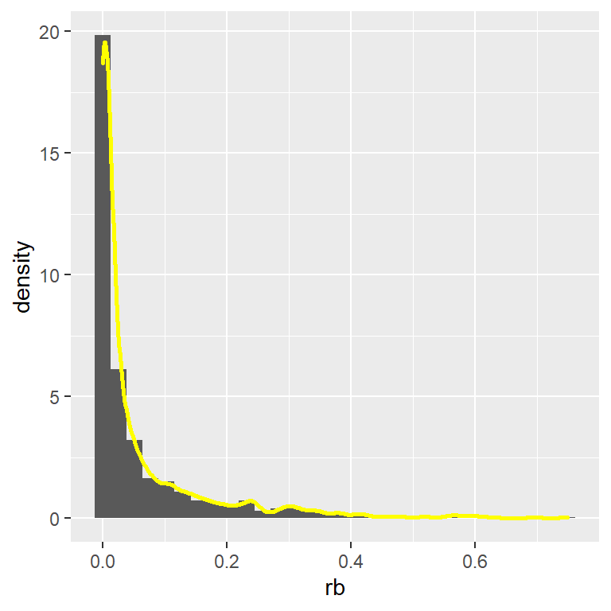

```r
num_sample <- 1000
sh1 <- 0.25
sh2 <- 4
ggplot(data.frame(rb=rbeta(n=num_sample, shape1=sh1, shape2 = sh2)), aes(x=rb))+geom_histogram(aes(y=..density..))+
  geom_density(color='yellow', size=1)
```

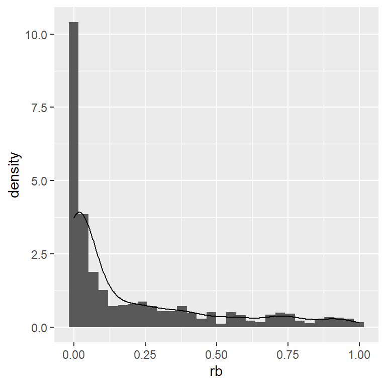

```r
num_sample <- 1000
sh1 <- 0.25
sh2 <- 1
ggplot(data.frame(rb=rbeta(n=num_sample, shape1=sh1, shape2 = sh2)), aes(x=rb))+geom_histogram(aes(y=..density..))+
  geom_density()
```

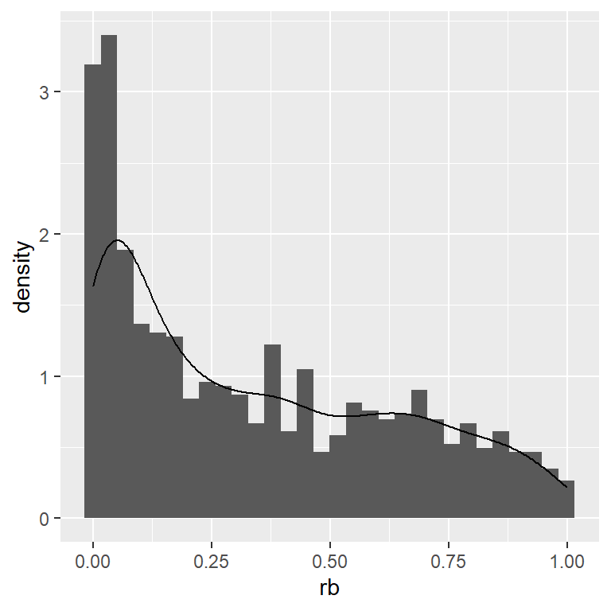

```r
num_sample <- 1000
sh1 <- 0.5
sh2 <- 1
ggplot(data.frame(rb=rbeta(n=num_sample, shape1=sh1, shape2 = sh2)), aes(x=rb))+geom_histogram(aes(y=..density..))+
  geom_density()
```

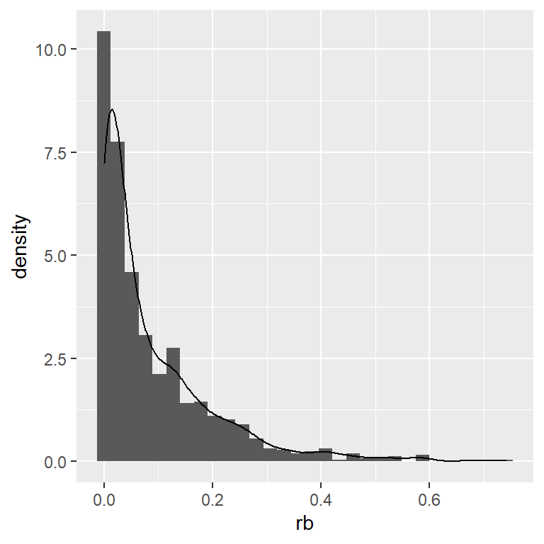

```r
num_sample <- 1000
sh1 <- 0.5
sh2 <- 5
ggplot(data.frame(rb=rbeta(n=num_sample, shape1=sh1, shape2 = sh2)), aes(x=rb))+geom_histogram(aes(y=..density..))+
  geom_density()
```

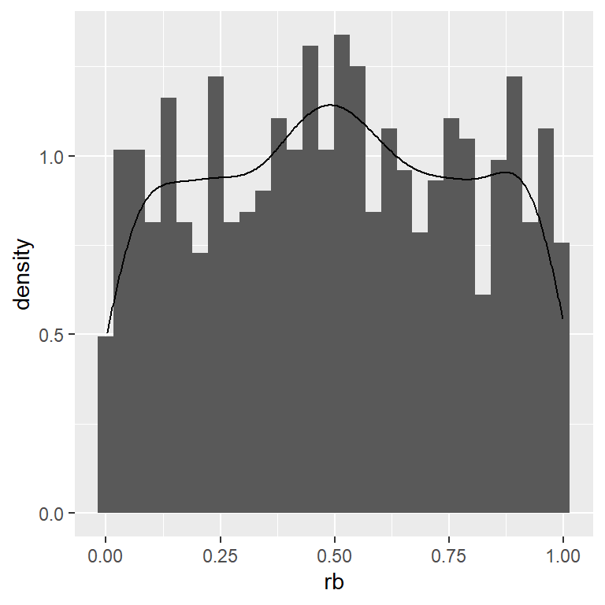

```r
num_sample <- 1000
sh1 <- 1
sh2 <- 1
ggplot(data.frame(rb=rbeta(n=num_sample, shape1=sh1, shape2 = sh2)), aes(x=rb))+geom_histogram(aes(y=..density..))+
  geom_density()
```

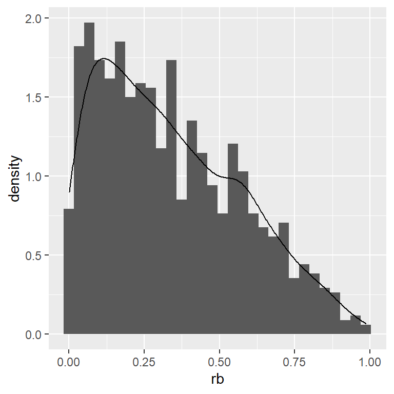

```r
num_sample <- 1000
sh1 <- 1
sh2 <- 2
ggplot(data.frame(rb=rbeta(n=num_sample, shape1=sh1, shape2 = sh2)), aes(x=rb))+geom_histogram(aes(y=..density..))+
  geom_density()
```

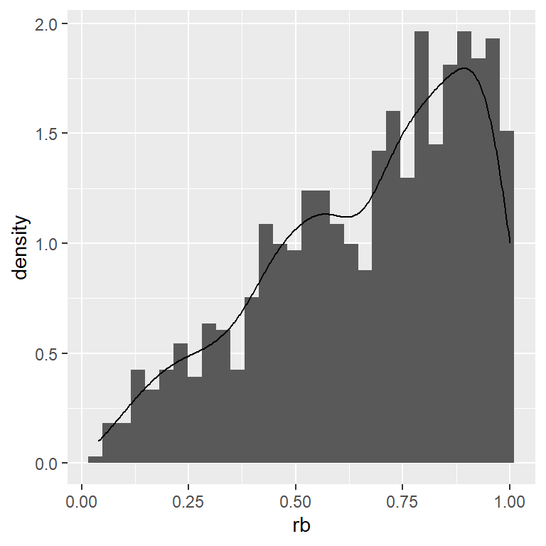

```r
num_sample <- 1000
sh1 <- 2
sh2 <- 1
ggplot(data.frame(rb=rbeta(n=num_sample, shape1=sh1, shape2 = sh2)), aes(x=rb))+geom_histogram(aes(y=..density..))+
  geom_density()
```

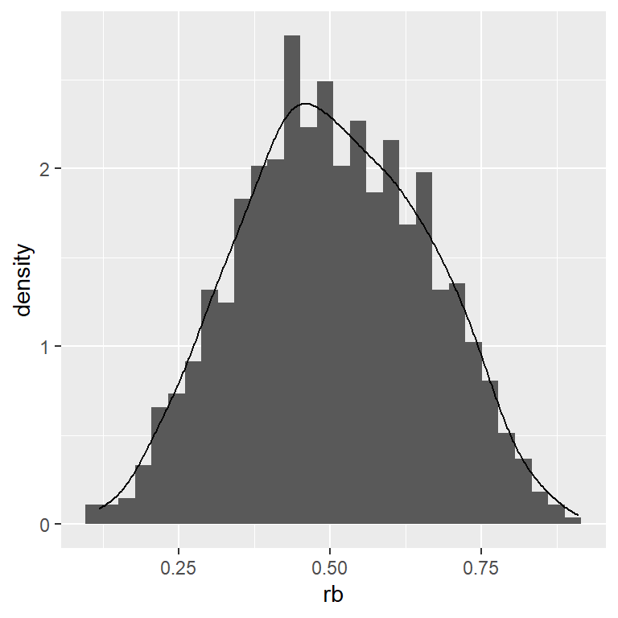

```r
num_sample <- 1000
sh1 <- 5
sh2 <- 5
ggplot(data.frame(rb=rbeta(n=num_sample, shape1=sh1, shape2 = sh2)), aes(x=rb))+geom_histogram(aes(y=..density..))+
  geom_density()
```

Duplicate beta distribution example for a/b test from https://www.countbayesie.com/blog/2015/3/3/6-amazing-trick-with-monte-carlo-simulations

For distribution of each test:

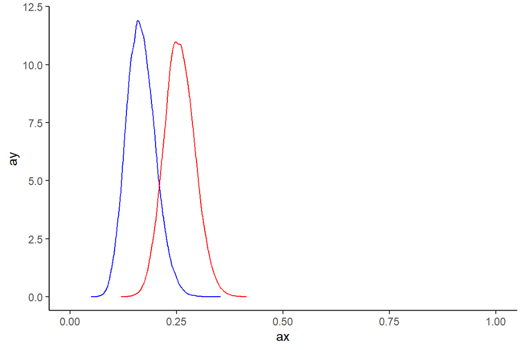

```r
num_sample <- 50000

# a test
convert <- 20
notconvert <- 100
acr <- convert/sum(convert, notconvert)

a <- rbeta(n=num_sample, shape1=convert, shape2=notconvert)
ad <- density(a)
#plot(ad)

# b test
convert <- 38
notconvert <- 110
bcr <- convert/sum(convert, notconvert)
b <- rbeta(n=num_sample, shape1=convert, shape2=notconvert)
bd <- density(b)
#plot(bd)

abd <- data.frame(ax=ad$x,
                  ay=ad$y,
                  bx=bd$x,
                  by=bd$y)

ggplot(abd)+geom_line(aes(x=ax, y=ay), color='blue')+
  geom_line(aes(x=bx, y=by), color='red')+
  scale_x_continuous(limits=c(0,1))+
  theme_classic()
```

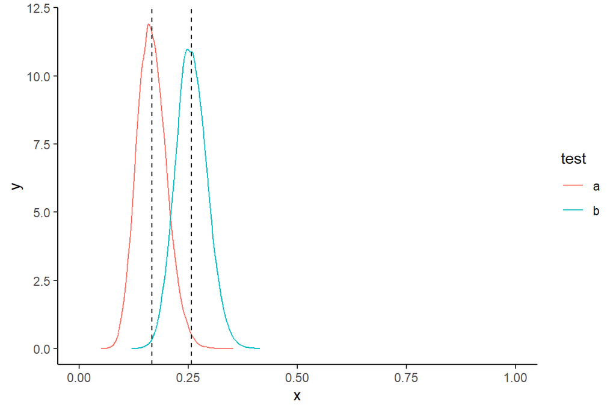

```r
## alternate approach to organizing data for display (tidy)
ad <- data.frame(test='a',
                  x=ad$x,
                  y=ad$y
                  )
bd <- data.frame(test='b',
                 x=bd$x,
                 y=bd$y)
abd <- bind_rows(ad, bd)

ggplot(abd, aes(x=x, y=y, color=test))+geom_line()+
  geom_vline(xintercept=acr, linetype='dashed')+
  geom_vline(xintercept=bcr, linetype='dashed')+
  scale_x_continuous(limits=c(0,1))+
  theme_classic()
```

Stats from a/b test:

- A conversion rate: 0.1666667
- B conversion rate: 0.2567568

Conversion rates very close to peak probability in chart (x-axis).